# DTSA 5510 Unsupervised Learning Final Project

## Using Supervised Learning Classifiers to Predict Student Success in School

## 0 - Project Topic

The topic of this work intends to model student achievement in secondary education using classification techniques, to evaluate if a good predictive accuracy could be achieved, based on student grades, demographic, social related features, with the aim of identifying the key variables that affect students' educational success/failure.

For achieving the objectives of this project, the study follows the overall process of knowledge discovery from data, consisting of:

1. Developing an understanding of the target dataset,
2. Removing noise and deciding on strategies for handling missing data fields,
3. Finding useful features to represent the data depending on the goal of the analysis,
4. Selecting the methods to be used for data sampling, and prediction,
5. Interpreting and evaluating the performance of the prediction models,
6. Concluding on the discovered knowledge.

For the analysis, multiple supervised and unsupervised learning techniques will applied and evaluated under a binary target variable consisting of the student's course success/failure, with the aim of understanding which specific techniques work better than the others.

As a result of this study, school resources could be better managed by targeting the most vulnerable students based on their demographic and social characteristics.

```python
##### added line to ensure plots are showing
%matplotlib inline
#####

# Installations
# pip install ucimlrepo
# pip install -U imbalanced-learn

# Libraries
from ucimlrepo import fetch_ucirepo
import matplotlib.pyplot as plt
import pandas as pd
import numpy as np
import seaborn as sea
import warnings

from sklearn.model_selection import train_test_split
from sklearn.metrics import accuracy_score
from sklearn.metrics import precision_score
from sklearn.metrics import roc_auc_score
from sklearn.metrics import confusion_matrix
```

## 1 - The Dataset

The dataset is *Student Performance*, donated by *Pablo Cortez* (2014), and published in *UC Irvine Machine Learning Repository*. The dataset includes the student grades, demographic, social and school related features for Portuguese language courses in two Portuguese schools. The data was collected by using school reports and questionnaires.

**Data size:** 154 KB  
**Instances:** 649  
**Features:** 30  
**Has Missing Values:** No  
**Link to dataset page:** https://archive.ics.uci.edu/dataset/320/student+performance

```python
# fetch dataset
student_performance = fetch_ucirepo(id=320)

# data as pandas dataframes
X = student_performance.data.features
y = student_performance.data.targets
```

```python
# Variables information
print(student_performance.variables)
```

```
          name     role         type      demographic  \
0       school  Feature  Categorical             None
1          sex  Feature       Binary              Sex
2          age  Feature      Integer              Age
3      address  Feature  Categorical             None
4      famsize  Feature  Categorical            Other
5      Pstatus  Feature  Categorical            Other
6         Medu  Feature      Integer  Education Level
7         Fedu  Feature      Integer  Education Level
8         Mjob  Feature  Categorical       Occupation
9         Fjob  Feature  Categorical       Occupation
10      reason  Feature  Categorical             None
11    guardian  Feature  Categorical             None
12  traveltime  Feature      Integer             None
13   studytime  Feature      Integer             None
```

[output cut: 54 more lines]

```python
# metadata
#print(student_performance.metadata)
```

## 2 - Data Cleaning

Let's address duplicated and missing values, outliers, unnecessary features, variables without predicting power, and categorical data.

### 2.2 Missing values

The *Dataset Information* page indicates that there are no missing values. However, let's do a quick check to verify the statement:

```python
X.isna().sum()
```

```
school        0
sex           0
age           0
address       0
famsize       0
Pstatus       0
Medu          0
Fedu          0
Mjob          0
Fjob          0
reason        0
guardian      0
traveltime    0
studytime     0
failures      0
schoolsup     0
famsup        0
paid          0
activities    0
nursery       0
higher        0
internet      0
romantic      0
famrel        0
freetime      0
goout         0
Dalc          0
Walc          0
health        0
absences      0
dtype: int64
```

```python
y.isna().sum()
```

```
G1    0
G2    0
G3    0
dtype: int64
```

No missing values either in the feature variables or in the target variables were found.

### 2.1 Duplicated values

Let's check on duplicated values:

```python
X.duplicated().value_counts()
```

```
False    649
dtype: int64
```

No duplicated values found in the dataset.

### 2.3 Outliers

Let's check on outliers by looking at the correlation among the first, second, and final grades, with the aim of identifying outliers, that may affect the performance of the model.

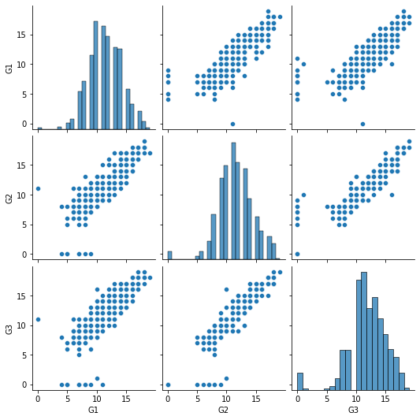

```python
sea.pairplot(y)
plt.show()
```

Looking at the pairplot we can observed some outliers in the student grades, which must be removed.

For detecting the outliers, we will use EllipticEnvelope from sklearn, by setting the proportion of outliers to be eliminated from the dataset:

```python
from sklearn.covariance import EllipticEnvelope
X_cln = X.copy()
y_cln = y.copy()
ee = EllipticEnvelope(contamination = 0.03)
outliers_ee = ee.fit_predict(y)
X_cln['outlier_ee'] = pd.DataFrame(outliers_ee)
y_cln['outlier_ee'] = pd.DataFrame(outliers_ee)

print(X_cln['outlier_ee'].value_counts())
```

```
 1    629
-1     20
Name: outlier_ee, dtype: int64
```

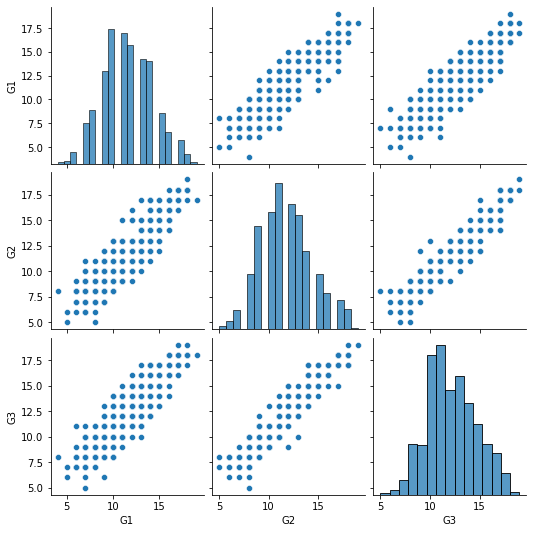

```python
y_cln = y_cln[y_cln['outlier_ee']==1]
y_cln = y_cln.drop(['outlier_ee'], axis=1)
X_cln = X_cln[X_cln['outlier_ee']==1]
X_cln = X_cln.drop(['outlier_ee'], axis=1)
sea.pairplot(y_cln)
plt.show()
```

The contamination was set at 3%, removing the most evident outliers observed in previous pairplot.

### 2.4 Feature Reduction

Let's drop unnecessary variables.

#### 2.4.1 Target Variables

Our aim is to predict the student's course success/failure, therefore, the focus will be based on the course *final grade (G3)*, discarding *first period grade (G1)* and *second period grade (G2)*:

```python
y_cln = y_cln.drop(['G1', 'G2'], axis=1)
```

#### 2.4.2 Feature Variables

The focus will be generating a model based on student's demographic and social features, not on the school related features. Therefore, the school features will be discarded:

```python
X_cln = X_cln.drop(['school', 'reason'], axis=1)
```

### 2.5 Transform Variables

Next, let's look at the types of data:

```python
X_cln.dtypes
```

```
sex           object
age            int64
address       object
famsize       object
Pstatus       object
Medu           int64
Fedu           int64
Mjob          object
Fjob          object
guardian      object
traveltime     int64
studytime      int64
failures       int64
schoolsup     object
famsup        object
paid          object
activities    object
nursery       object
higher        object
internet      object
romantic      object
famrel         int64
freetime       int64
goout          int64
Dalc           int64
Walc           int64
health         int64
absences       int64
dtype: object
```

```python
y_cln.dtypes
```

```
G3    int64
dtype: object
```

Looking at the attributes of the data, most of the prediction variables are categorical, except for *age*, *failures*, and *absences*. For the categorical variables, some are ordinal, and some are nominal. For the nominal variables, we will encode the variables (which involves transforming the column into multiple binary columns), as most classification algorithms are primarily designed to operate with numerical data only.

Let's encode the nominal variables:

```python
# Transform all object type variables
list_str_obj_cols = X_cln.columns[X_cln.dtypes == "object"].tolist()
X_trf = pd.get_dummies(X_cln, prefix=list_str_obj_cols, columns=list_str_obj_cols
                    , drop_first=True)
```

```python
# Display results
X_trf.dtypes
```

```
age                int64
Medu               int64
Fedu               int64
traveltime         int64
studytime          int64
failures           int64
famrel             int64
freetime           int64
goout              int64
Dalc               int64
Walc               int64
health             int64
absences           int64
sex_M              uint8
address_U          uint8
famsize_LE3        uint8
Pstatus_T          uint8
Mjob_health        uint8
Mjob_other         uint8
Mjob_services      uint8
Mjob_teacher       uint8
Fjob_health        uint8
Fjob_other         uint8
Fjob_services      uint8
Fjob_teacher       uint8
guardian_mother    uint8
guardian_other     uint8
schoolsup_yes      uint8
famsup_yes         uint8
paid_yes           uint8
activities_yes     uint8
nursery_yes        uint8
higher_yes         uint8
internet_yes       uint8
romantic_yes       uint8
dtype: object
```

```python
X_trf.head()
```

|  | age | Medu | Fedu | traveltime | studytime | failures | famrel | freetime | goout | Dalc | ... | guardian_mother | guardian_other | schoolsup_yes | famsup_yes | paid_yes | activities_yes | nursery_yes | higher_yes | internet_yes | romantic_yes |
| --- | --- | --- | --- | --- | --- | --- | --- | --- | --- | --- | --- | --- | --- | --- | --- | --- | --- | --- | --- | --- | --- |
| 1 | 17 | 1 | 1 | 1 | 2 | 0 | 5 | 3 | 3 | 1 | ... | 0 | 0 | 0 | 1 | 0 | 0 | 0 | 1 | 1 | 0 |
| 2 | 15 | 1 | 1 | 1 | 2 | 0 | 4 | 3 | 2 | 2 | ... | 1 | 0 | 1 | 0 | 0 | 0 | 1 | 1 | 1 | 0 |
| 3 | 15 | 4 | 2 | 1 | 3 | 0 | 3 | 2 | 2 | 1 | ... | 1 | 0 | 0 | 1 | 0 | 1 | 1 | 1 | 1 | 1 |
| 4 | 16 | 3 | 3 | 1 | 2 | 0 | 4 | 3 | 2 | 1 | ... | 0 | 0 | 0 | 1 | 0 | 0 | 1 | 1 | 0 | 0 |
| 5 | 16 | 4 | 3 | 1 | 2 | 0 | 5 | 4 | 2 | 1 | ... | 1 | 0 | 0 | 1 | 0 | 1 | 1 | 1 | 1 | 0 |

5 rows × 35 columns

In the case of the target variable (*final score G3*), it will be converted into a pass/fail (binary) class, pass if G3≥10, else fail:

```python
y_trf = y_cln.copy()
# fail
y_trf[y_trf['G3']<10] = 0
# pass
y_trf[y_trf['G3']>=10] = 1

y_trf.value_counts()
```

```
G3
1     546
0      83
dtype: int64
```

## 3 - Exploratory Data Analysis

### 3.1 Data Distribution Analysis

Let's get an idea of the distribution of the variables by plotting a histogram of each feature variable:

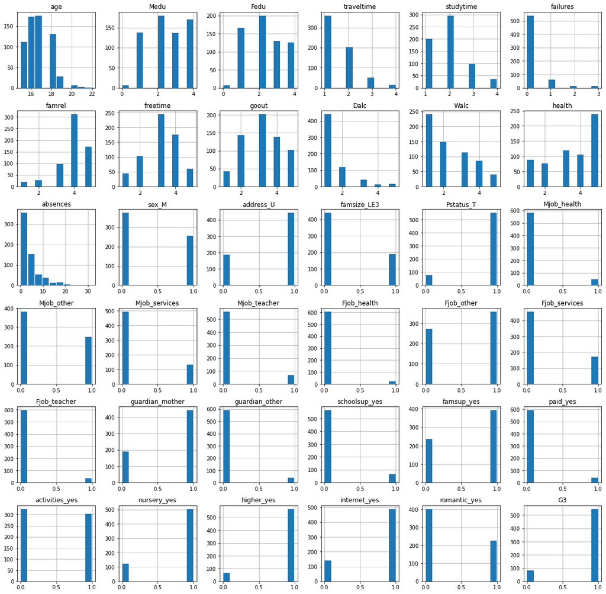

```python
df = X_trf.copy()
df['G3'] = y_trf['G3']
df.hist(figsize=(20,20), zorder=2, rwidth=0.9)
plt.show()
```

From the histograms, we can observe some skewness, and outliers on some of the feature variables such as *age*. However, the most concerning finding is the class imbalance in the target variable *G3*, that must be mitigated using oversampling techniques.

### 3.2 Imbalance Classes

Prediction performance will be affected by the imbalanced of the target variable *G3*, corresponding to the difference of the number of samples in the two classes (pass/fail).

Let's visualize the effect of two oversampling techniques on handling the class imbalance in the target variable *G3*:

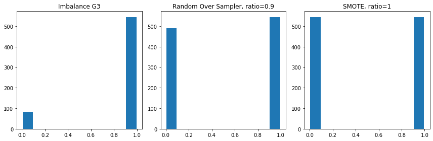

```python
from imblearn.over_sampling import RandomOverSampler
from imblearn.under_sampling import RandomUnderSampler
from imblearn.over_sampling import SMOTE

# RandomOverSampler
ros = RandomOverSampler(sampling_strategy=0.9, random_state=42)
X_ros, y_ros = ros.fit_resample(X_trf, y_trf)

# SMOTE
smt = SMOTE(sampling_strategy=1, random_state=42)
X_smt, y_smt = smt.fit_resample(X_trf, y_trf)

#define subplots
fig, ax = plt.subplots(1,3,figsize=(12,4))

# Imbalance class
plt.subplot(1,3,1)
plt.hist(y_trf,rwidth=0.90)
plt.title('Imbalance G3')

# RandomOverSampler
plt.subplot(1,3,2)
plt.hist(y_ros,rwidth=0.90)
plt.title('Random Over Sampler, ratio=0.9')

# SMOTE
plt.subplot(1,3,3)
plt.hist(y_smt,rwidth=0.90)
plt.title('SMOTE, ratio=1')

fig.tight_layout(h_pad=20)

#display subplots
plt.show()
```

- *RandomOver Sample* over-samples the minority class by picking samples at random with replacement.
- *SMOTE* over-samples the minority class by synthesizing new synthetic data close to the other points belonging to the minority class.

### 3.3 Correlation Analysis

Let's visualize which features seem to be correlated, and which are related to the target variable *G3*, by plotting a correlation matrix:

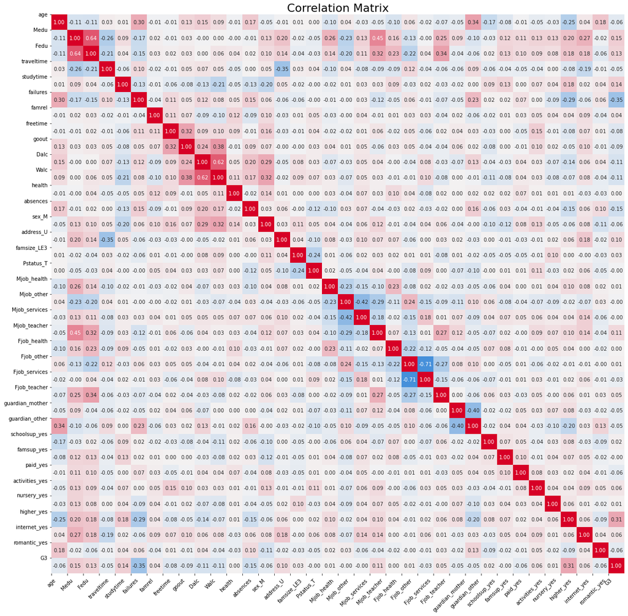

```python
correlation = df.corr()

fig, ax = plt.subplots(figsize=(20,20))         # Sample figsize in inches
rdgn = sea.diverging_palette(h_neg=255, h_pos=10, s=100, l=45, n=256, sep=1, as_cmap=True)
sea.heatmap(data=correlation, cmap =rdgn, center = 0, fmt=".2f", annot=True, annot_kws={'fontname': 'sans-serif', 'size': 10}, cbar=False)

ticks = np.arange(0,len(df.columns),1)
ax.set_xticks(ticks)
ax.set_yticks(ticks)

for tick in ax.get_xticklabels():
    tick.set_rotation(45)

ax.set_xticklabels(df.columns)
ax.set_yticklabels(df.columns)
ax.set_title( "Correlation Matrix" , size = 22 )
plt.show()
```

By looking at the correlation matrix, we can observe that most of feature variables are not strongly correlated to the target variable *G3*, being the top 5 most correlated features:

1. failures
2. higher_yes
3. Medu
4. absences
5. studytime

Moreover, some features strongly correlated among themselves, such as: between *Medu* and *Fedu*, between *Dalc* and *Walc*, and between *Fjob_services* and *Fjob_other*.

### 3.4 Feature Importance

Let's normalize the data before performing the feature importance analysis for preventing features with larger scales dominating the process.

```python
### Normalization
from sklearn.preprocessing import normalize

X_nrm = normalize(X_trf)
```

Let's research on features importance using *SelectKBest* from *sklearn:*

```python
from sklearn.feature_selection import SelectKBest
from sklearn.feature_selection import chi2, mutual_info_classif
```

```python
print("Top 5 features by Chi-squared:")
selected_features = SelectKBest(chi2, k=5).fit(X_nrm, y_trf.values.ravel())
for feature_name, selected in zip(X_trf.columns, selected_features.get_support()):
    if selected:
        print("-", feature_name)
```

```
Top 5 features by Chi-squared:
- Medu
- Fedu
- failures
- absences
- Mjob_teacher
```

```python
print("Top 5 features by Mutual information for Classification:")
selected_features = SelectKBest(mutual_info_classif, k=5).fit(X_nrm, y_trf.values.ravel())
for feature_name, selected in zip(X_trf.columns, selected_features.get_support()):
    if selected:
        print("-", feature_name)
```

```
Top 5 features by Mutual information for Classification:
- Medu
- failures
- address_U
- higher_yes
- internet_yes
```

Next, let's check what variables are important using PCA, by plotting a Scree plot:

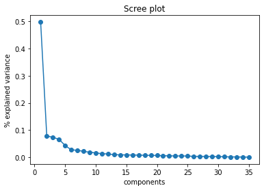

```python
from sklearn.decomposition import PCA

pca = PCA()
pca.fit(X_nrm)

plt.plot(range(1,len(pca.components_)+1),pca.explained_variance_ratio_,'-o')
plt.xlabel('components')
plt.ylabel('% explained variance')
plt.title("Scree plot")
plt.show()
```

```python
interesting_variables = set()
threshold = 0.2
variables = []
weights = []

for index in range(0,6):

    for weight, variable in zip(pca.components_[index], X_trf.columns):

        if np.abs(weight) > threshold:
            variables.append(variable)
            weights.append(weight)
            #print(index)
            #print(variable)
            #print(weight)

interesting_variables = set(variables)

print("Top features by PCA:")
print(interesting_variables)
```

```
Top features by PCA:
{'Medu', 'health', 'absences', 'age', 'Dalc', 'Fedu', 'freetime', 'Walc', 'goout', 'famrel'}
```

All in all, we can observe from the different methods that the most important features are:

- Medu
- Fedu
- absences
- failures
- higher_yes

Feasure selection techniques will be applied during the modelling tasks.

## 4 - Modeling

### 4.1 Supervised Model Selection Process

Let's prepare the *Supervised Learning* modeling setup by making a function that applies different techniques on:

1. Standardization
2. Oversampling
3. Feature Selection
4. Cross Validation
5. Classification

Then, returns the performing model, three evaluation metrics: accuracy, precision and auroc, resulting from the mean over the number of CV folds, and the mean of the three metrics (mean score).

```python
from sklearn.preprocessing import StandardScaler
from sklearn.preprocessing import Normalizer
#from sklearn.pipeline import Pipeline
from imblearn.pipeline import Pipeline
from sklearn.model_selection import cross_validate
from sklearn.tree import DecisionTreeClassifier as DT
from sklearn.ensemble import RandomForestClassifier as RF
from sklearn.ensemble import AdaBoostClassifier as AB
from sklearn.svm import SVC
from sklearn.model_selection import StratifiedKFold
from sklearn.model_selection import ShuffleSplit
from sklearn.model_selection import StratifiedShuffleSplit

def SL_selection_process(X_train, y_train, stdr, osr, st, fs, cv, nf, clsfr):

    np.random.seed(42)

    ppln_steps = []

    # Standardizer
    if stdr == 'SS':
        ppln_steps.append(('scaler', StandardScaler()))

    elif stdr == 'NM':
        ppln_steps.append(('normalizer', Normalizer()))

    # Oversampler
    if osr == 'ROS':
        ppln_steps.append(('ROS', RandomOverSampler(sampling_strategy='auto', random_state=42)))

    elif osr == 'SM':
        ppln_steps.append(('SMOTE', SMOTE(sampling_strategy='auto', random_state=42)))

    # Features Selection
    if st == 'PCA':
        ppln_steps.append(('PCA', PCA(n_components=fs)))

    elif st == 'chi2':
        ppln_steps.append(('chi2', SelectKBest(chi2, k=fs)))

    elif st == 'MI':
        ppln_steps.append(('mutual_information', SelectKBest(mutual_info_classif, k=fs)))

    # Cross-validator
    if cv == 'SKF':
        cv = StratifiedKFold(n_splits=nf, shuffle=True, random_state=42)

    elif cv == 'SS':
        cv = ShuffleSplit(n_splits=nf, test_size=.25, random_state=42)

    else:
        cv = nf

    # Metrics
    metrics = ['accuracy', 'precision', 'roc_auc']

    # Model
    if clsfr == 'DT':
        ppln_steps.append(('DT', DT()))

    elif clsfr == 'RF':
        ppln_steps.append(('RF', RF()))

    elif clsfr == 'AB':
        ppln_steps.append(('AB', AB()))

    elif clsfr == 'SVC':
        ppln_steps.append(('SVC', SVC()))

    # Pipeline
    #print(ppln_steps)
    pipe = Pipeline(steps=ppln_steps)

    # Cross Validation
    outcomes = cross_validate(pipe, X_train, y_train, scoring=metrics, cv=cv, return_train_score=False)

    accuracy = np.mean(outcomes['test_accuracy'])
    precision = np.mean(outcomes['test_precision'])
    auroc = np.mean(outcomes['test_roc_auc'])

    ###

    return accuracy, precision, auroc, ppln_steps
```

Let's evaluate different pre-processing techniques and classification algorithms (using their default hyperparameter values) to find the best setups:

```python
warnings.filterwarnings("ignore")

# Split dataset into a train subset and a test subset
X_train, X_test, y_train, y_test = train_test_split(X_trf, y_trf, test_size = 0.3, random_state=42)

# Techniques:
stdrs = ['SS', 'NM']
osrs = ['None', 'ROS', 'SM']
sts = ['None', 'PCA', 'chi2', 'MI']
fss = [5, 10, 15]
cvs = ['CV', 'SKF', 'SS']
nfs = [5]
clsfrs = ['DT', 'RF', 'AB', 'SVC']

# iteration values list
i_stdr = []
i_osr = []
i_st = []
i_fs = []
i_cv = []
i_nf = []
i_clsfr = []
i_acc = []
i_prc = []
i_roc = []
i_score = []
i_steps = []

# Evaluate different models setups:
# stdr, osr, st, fs, cv, nf, clsfr

for clsfr in clsfrs:
    for cv in cvs:
        for nf in nfs:
            for stdr in stdrs:
                for osr in osrs:
                    for st in sts:
                        if st=='None':

                            fs='None'
                            acc, prc, roc, stp = SL_selection_process(X_train, y_train, stdr, osr, st, fs, cv, nf, clsfr)
                            avg_score = np.mean([acc, prc, roc])

                            # store input/result values
                            i_stdr.append(stdr)
                            i_osr.append(osr)
                            i_st.append(st)
                            i_fs.append(fs)
                            i_cv.append(cv)
                            i_nf.append(nf)
                            i_clsfr.append(clsfr)
                            i_acc.append(acc)
                            i_prc.append(prc)
                            i_roc.append(roc)
                            i_score.append(avg_score)
                            i_steps.append(stp)

                        elif (st=='chi2' and stdr=='SS'):
                            # chi2 doesn't process negative values generated from StandardScaler
                            continue

                        else:
                            for fs in fss:
                                #print(stdr, osr, st, fs, cv, nf, clsfr)
                                acc, prc, roc, stp = SL_selection_process(X_train, y_train, stdr, osr, st, fs, cv, nf, clsfr)
                                avg_score = np.mean([acc, prc, roc])

                                # store input/result values
                                i_stdr.append(stdr)
                                i_osr.append(osr)
                                i_st.append(st)
                                i_fs.append(fs)
                                i_cv.append(cv)
                                i_nf.append(nf)
                                i_clsfr.append(clsfr)
                                i_acc.append(acc)
                                i_prc.append(prc)
                                i_roc.append(roc)
                                i_score.append(avg_score)
                                i_steps.append(stp)

SL_dict_eval = {'Classifier': i_clsfr, 'cv': i_cv, 'nf': i_nf, 'stdr': i_stdr, 'osr':i_osr, 'st': i_st, 'fs': i_fs,
              'acc': i_acc, 'prc': i_prc, 'roc': i_roc, 'avg_score': i_score, 'steps': i_steps}

SL_df_eval = pd.DataFrame(SL_dict_eval)
```

Let's get a glimpse of the results of the model selection process:

```python
SL_df_eval
```

|  | Classifier | cv | nf | stdr | osr | st | fs | acc | prc | roc | avg_score | steps |
| --- | --- | --- | --- | --- | --- | --- | --- | --- | --- | --- | --- | --- |
| 0 | DT | CV | 5 | SS | None | None | None | 0.795455 | 0.875830 | 0.581128 | 0.750804 | [(scaler, StandardScaler()), (DT, DecisionTree... |
| 1 | DT | CV | 5 | SS | None | PCA | 5 | 0.779545 | 0.861445 | 0.533641 | 0.724877 | [(scaler, StandardScaler()), (PCA, PCA(n_compo... |
| 2 | DT | CV | 5 | SS | None | PCA | 10 | 0.768182 | 0.872184 | 0.565128 | 0.735165 | [(scaler, StandardScaler()), (PCA, PCA(n_compo... |
| 3 | DT | CV | 5 | SS | None | PCA | 15 | 0.786364 | 0.872662 | 0.569436 | 0.742820 | [(scaler, StandardScaler()), (PCA, PCA(n_compo... |
| 4 | DT | CV | 5 | SS | None | MI | 5 | 0.854545 | 0.896116 | 0.667590 | 0.806084 | [(scaler, StandardScaler()), (mutual_informati... |
| ... | ... | ... | ... | ... | ... | ... | ... | ... | ... | ... | ... | ... |
| 607 | SVC | SS | 5 | NM | SM | chi2 | 10 | 0.763636 | 0.921208 | 0.773967 | 0.819604 | [(normalizer, Normalizer()), (SMOTE, SMOTE(ran... |
| 608 | SVC | SS | 5 | NM | SM | chi2 | 15 | 0.760000 | 0.930210 | 0.774177 | 0.821463 | [(normalizer, Normalizer()), (SMOTE, SMOTE(ran... |
| 609 | SVC | SS | 5 | NM | SM | MI | 5 | 0.758182 | 0.896429 | 0.713748 | 0.789453 | [(normalizer, Normalizer()), (SMOTE, SMOTE(ran... |
| 610 | SVC | SS | 5 | NM | SM | MI | 10 | 0.732727 | 0.897130 | 0.688918 | 0.772925 | [(normalizer, Normalizer()), (SMOTE, SMOTE(ran... |
| 611 | SVC | SS | 5 | NM | SM | MI | 15 | 0.781818 | 0.909722 | 0.728331 | 0.806624 | [(normalizer, Normalizer()), (SMOTE, SMOTE(ran... |

612 rows × 12 columns

Let's display the best setup based on cross-validation performance:

```python
# The best setup:
best_SL_setup = SL_df_eval[SL_df_eval['avg_score']==SL_df_eval['avg_score'].max()]
best_SL_setup
```

|  | Classifier | cv | nf | stdr | osr | st | fs | acc | prc | roc | avg_score | steps |
| --- | --- | --- | --- | --- | --- | --- | --- | --- | --- | --- | --- | --- |
| 180 | RF | CV | 5 | NM | None | chi2 | 15 | 0.863636 | 0.876154 | 0.84359 | 0.861127 | [(normalizer, Normalizer()), (chi2, SelectKBes... |

We can observe that the best supervised learning model with an average score of 86.11% is a *Random Forest Classifier*, based on fifteen (15) features, selected using *chi squared* feature selection technique, without *oversampling*, and evaluated using five (5) folds cross-validation.

### 4.2 Unsupervised Model Selection Process

Now, for *Unsupervised Learning*, let's build different models and applying techniques such as:

- Non-Negative Matrix Factorization (NMF)
- KMeans

trained using the entire dataset (`X_trf`, `y_trf`), and tuned by testing different combinations of hyperparameters, and oversampling to address the imbalance classes. The best unsupervised model setup for each classifier will be selected based on the performance against the training set.

```python
def labels_permutation(lbls, y_true, y_pdn):
    """Search the best arrangement between output lables"""

    nlst = lbls.copy()
    dict_fnl = {}

    for i in range(len(lbls)):
        dict_tmp = dict_fnl.copy()
        dict_acc = {}
        for lbl in nlst:
            # Assign a label to components
            dict_tmp[i] = lbl
            y_pred = [dict_tmp.get(item, "unknown") for item in y_pdn]

            # Calculating the accuracy
            dict_acc[round(accuracy_score(y_true, y_pred), 4)] = lbl

        # Selecting the best arrangement component-label
        acc_lbls = list(dict_acc.keys())
        acc_lbls.sort(reverse=True)
        dict_fnl[i] = dict_acc[acc_lbls[0]]
        nlst.remove(dict_fnl[i])
        #print(dict_fnl)
        #print(nlst)

    return dict_fnl
```

#### 4.2.1 Non-Negative Matrix Factorization (NMF)

```python
warnings.filterwarnings("ignore")
from sklearn.decomposition import NMF

# Note: for the unsupervised learning technique we will use the entire dataset
# to train the model, instead of the training set

# Parameters to evaluate:
inits = ['random', 'nndsvd', 'nndsvda', 'nndsvdar']
solvers = ['cd', 'mu']
beta_losses = ['frobenius', 'kullback-leibler']
osrs = ['None', 'ROS', 'SM']

# Iteration values list
i_osr = []
i_init = []
i_solver = []
i_bl = []
i_acc = []
i_prc = []
i_roc = []
i_score = []

# Evaluate different setups:

# Oversampler
for osr in osrs:
    if osr=='ROS':
        ros = RandomOverSampler(sampling_strategy='auto', random_state=42)
        X_eval, y_eval = ros.fit_resample(X_trf, y_trf)
    elif osr=='SM':
        sm = SMOTE(sampling_strategy='auto', random_state=42)
        X_eval, y_eval = sm.fit_resample(X_trf, y_trf)
    else:
        X_eval = X_trf.copy()
        y_eval = y_trf.copy()

    for init in inits:
        for solver in solvers:
            for beta_loss in beta_losses:
                if solver in ['cd'] and beta_loss in ['kullback-leibler']:
                    continue

                # Initiate classifier with two (2) components
                NMF_md = NMF(n_components=2, random_state=42,
                             init=init, solver=solver,
                             beta_loss=beta_loss).fit(X_eval)

                # Decompose the training feature matrix into a component matrix
                y_trf_train = NMF_md.transform(X_train)

                # Select the best component
                y_pdn_train = y_trf_train.argmax(axis=1)
                #print(y_pdn_train)

                # Assign a label to the components
                cat_lbls = [0, 1]
                num_to_cat = labels_permutation(cat_lbls, y_train, y_pdn_train)
                y_pred_train = [num_to_cat.get(item, "unknown") for item in y_pdn_train]

                # Calculating the accuracy
                acc = round(accuracy_score(y_train, y_pred_train), 4)
                prc = round(precision_score(y_train, y_pred_train), 4)
                roc = round(roc_auc_score(y_train, y_pred_train), 4)
                avg_score = np.mean([acc, prc, roc])

                # store input/result values
                i_osr.append(osr)
                i_init.append(init)
                i_solver.append(solver)
                i_bl.append(beta_loss)
                i_acc.append(acc)
                i_prc.append(prc)
                i_roc.append(roc)
                i_score.append(avg_score)

                #print(init, solver, beta_loss, acc)

NMF_dict_eval = {'Classifier': 'NMF', 'osr':i_osr, 'init': i_init, 'solver': i_solver, 'beta_loss': i_bl,
             'acc': i_acc, 'prc': i_prc, 'roc': i_roc, 'avg_score': i_score}

NMF_df_eval = pd.DataFrame(NMF_dict_eval)
NMF_df_eval
```

|  | Classifier | osr | init | solver | beta_loss | acc | prc | roc | avg_score |
| --- | --- | --- | --- | --- | --- | --- | --- | --- | --- |
| 0 | NMF | None | random | cd | frobenius | 0.5864 | 0.8755 | 0.5538 | 0.671900 |
| 1 | NMF | None | random | mu | frobenius | 0.7341 | 0.8728 | 0.5642 | 0.723700 |
| 2 | NMF | None | random | mu | kullback-leibler | 0.6818 | 0.8983 | 0.6226 | 0.734233 |
| 3 | NMF | None | nndsvd | cd | frobenius | 0.8091 | 0.8557 | 0.5128 | 0.725867 |
| 4 | NMF | None | nndsvd | mu | frobenius | 0.8068 | 0.8554 | 0.5115 | 0.724567 |
| 5 | NMF | None | nndsvd | mu | kullback-leibler | 0.8114 | 0.8561 | 0.5142 | 0.727233 |
| 6 | NMF | None | nndsvda | cd | frobenius | 0.7909 | 0.8564 | 0.5149 | 0.720733 |
| 7 | NMF | None | nndsvda | mu | frobenius | 0.7545 | 0.8719 | 0.5635 | 0.729967 |
| 8 | NMF | None | nndsvda | mu | kullback-leibler | 0.7545 | 0.8719 | 0.5635 | 0.729967 |
| 9 | NMF | None | nndsvdar | cd | frobenius | 0.8091 | 0.8557 | 0.5128 | 0.725867 |
| 10 | NMF | None | nndsvdar | mu | frobenius | 0.7977 | 0.8575 | 0.5189 | 0.724700 |
| 11 | NMF | None | nndsvdar | mu | kullback-leibler | 0.8114 | 0.8578 | 0.5205 | 0.729900 |
| 12 | NMF | ROS | random | cd | frobenius | 0.6659 | 0.8800 | 0.5751 | 0.707000 |
| 13 | NMF | ROS | random | mu | frobenius | 0.7455 | 0.8725 | 0.5645 | 0.727500 |
| 14 | NMF | ROS | random | mu | kullback-leibler | 0.7227 | 0.8799 | 0.5830 | 0.728533 |
| 15 | NMF | ROS | nndsvd | cd | frobenius | 0.8136 | 0.8564 | 0.5155 | 0.728500 |
| 16 | NMF | ROS | nndsvd | mu | frobenius | 0.8227 | 0.8578 | 0.5208 | 0.733767 |
| 17 | NMF | ROS | nndsvd | mu | kullback-leibler | 0.8182 | 0.8571 | 0.5182 | 0.731167 |
| 18 | NMF | ROS | nndsvda | cd | frobenius | 0.7727 | 0.8590 | 0.5233 | 0.718333 |
| 19 | NMF | ROS | nndsvda | mu | frobenius | 0.7568 | 0.8722 | 0.5648 | 0.731267 |
| 20 | NMF | ROS | nndsvda | mu | kullback-leibler | 0.7523 | 0.8715 | 0.5622 | 0.728667 |
| 21 | NMF | ROS | nndsvdar | cd | frobenius | 0.8136 | 0.8564 | 0.5155 | 0.728500 |
| 22 | NMF | ROS | nndsvdar | mu | frobenius | 0.8023 | 0.8547 | 0.5088 | 0.721933 |
| 23 | NMF | ROS | nndsvdar | mu | kullback-leibler | 0.8182 | 0.8571 | 0.5182 | 0.731167 |
| 24 | NMF | SM | random | cd | frobenius | 0.6364 | 0.8772 | 0.5641 | 0.692567 |
| 25 | NMF | SM | random | mu | frobenius | 0.7455 | 0.8725 | 0.5645 | 0.727500 |
| 26 | NMF | SM | random | mu | kullback-leibler | 0.7159 | 0.8743 | 0.5663 | 0.718833 |
| 27 | NMF | SM | nndsvd | cd | frobenius | 0.8091 | 0.8557 | 0.5128 | 0.725867 |
| 28 | NMF | SM | nndsvd | mu | frobenius | 0.8136 | 0.8564 | 0.5155 | 0.728500 |
| 29 | NMF | SM | nndsvd | mu | kullback-leibler | 0.8136 | 0.8547 | 0.5091 | 0.725800 |
| 30 | NMF | SM | nndsvda | cd | frobenius | 0.7705 | 0.8549 | 0.5092 | 0.711533 |
| 31 | NMF | SM | nndsvda | mu | frobenius | 0.7614 | 0.8689 | 0.5548 | 0.728367 |
| 32 | NMF | SM | nndsvda | mu | kullback-leibler | 0.7636 | 0.8633 | 0.5370 | 0.721300 |
| 33 | NMF | SM | nndsvdar | cd | frobenius | 0.8091 | 0.8557 | 0.5128 | 0.725867 |
| 34 | NMF | SM | nndsvdar | mu | frobenius | 0.8000 | 0.8561 | 0.5138 | 0.723300 |
| 35 | NMF | SM | nndsvdar | mu | kullback-leibler | 0.8114 | 0.8544 | 0.5078 | 0.724533 |

Based on the results, let's choose the best setup for the NMF unsupervised learning model:

```python
best_NMF_setup = NMF_df_eval[NMF_df_eval['avg_score']==NMF_df_eval['avg_score'].max()]
best_NMF_setup
```

|  | Classifier | osr | init | solver | beta_loss | acc | prc | roc | avg_score |
| --- | --- | --- | --- | --- | --- | --- | --- | --- | --- |
| 2 | NMF | None | random | mu | kullback-leibler | 0.6818 | 0.8983 | 0.6226 | 0.734233 |

We can observe that the best **NMF** setup consists of no *oversampling*, with a *random* initiation method, a *Multiplicative Update* solver, and a *kullback-leibler* beta divergence to be minimized, achieving an average score of 73.42%.

#### 4.2.2 K-Means Clustering

```python
warnings.filterwarnings("ignore")
from sklearn.cluster import KMeans

# Note: for the unsupervised learning technique we will use the entire dataset
# to train the model, instead of the training set

# Parameters to evaluate:
osrs = ['None', 'ROS', 'SM']
inits = ['k-means++', 'random']
algorthms = ['auto', 'full', 'elkan']
max_iters = [300, 500, 700]

# Iteration values list
i_osr = []
i_init = []
i_alg = []
i_mxi = []
i_acc = []
i_prc = []
i_roc = []
i_score = []

# Evaluate different setups:
# Oversampler
for osr in osrs:
    if osr=='ROS':
        ros = RandomOverSampler(sampling_strategy='auto', random_state=42)
        X_eval, y_eval = ros.fit_resample(X_trf, y_trf)
    elif osr=='SM':
        sm = SMOTE(sampling_strategy='auto', random_state=42)
        X_eval, y_eval = sm.fit_resample(X_trf, y_trf)
    else:
        X_eval = X_trf.copy()
        y_eval = y_trf.copy()

    for init in inits:
        for algorithm in algorthms:
            for max_iter in max_iters:

                # Initiate classifier with two (2) clusters
                KM_md = KMeans(n_clusters=2, random_state=42, init=init,
                               max_iter=max_iter, algorithm=algorithm).fit(X_eval)

                #print(KM_md.labels_)

                # Predict the lables for the training set
                y_pdn_train = KM_md.predict(X_train)
                #print(y_pdn_train)

                # Assign a label to the components
                cat_lbls = [0, 1]
                num_to_cat = labels_permutation(cat_lbls, y_train, y_pdn_train)
                y_pred_train = [num_to_cat.get(item, "unknown") for item in y_pdn_train]

                # Calculating the accuracy
                acc = round(accuracy_score(y_train, y_pred_train), 4)
                prc = round(precision_score(y_train, y_pred_train), 4)
                roc = round(roc_auc_score(y_train, y_pred_train), 4)
                avg_score = np.mean([acc, prc, roc])

                # store input/result values
                i_osr.append(osr)
                i_init.append(init)
                i_alg.append(algorithm)
                i_mxi.append(max_iter)
                i_acc.append(acc)
                i_prc.append(prc)
                i_roc.append(roc)
                i_score.append(avg_score)

            #print(init, solver, beta_loss, acc)

KM_dict_eval = {'Classifier': 'KMeans', 'osr':i_osr, 'init': i_init, 'algorithm': i_alg, 'max_iter': i_mxi,
             'acc': i_acc, 'prc': i_prc, 'roc': i_roc, 'avg_score': i_score}

KM_df_eval = pd.DataFrame(KM_dict_eval)
KM_df_eval
```

|  | Classifier | osr | init | algorithm | max_iter | acc | prc | roc | avg_score |
| --- | --- | --- | --- | --- | --- | --- | --- | --- | --- |
| 0 | KMeans | None | k-means++ | auto | 300 | 0.7455 | 0.8725 | 0.5645 | 0.727500 |
| 1 | KMeans | None | k-means++ | auto | 500 | 0.7455 | 0.8725 | 0.5645 | 0.727500 |
| 2 | KMeans | None | k-means++ | auto | 700 | 0.7455 | 0.8725 | 0.5645 | 0.727500 |
| 3 | KMeans | None | k-means++ | full | 300 | 0.7455 | 0.8725 | 0.5645 | 0.727500 |
| 4 | KMeans | None | k-means++ | full | 500 | 0.7455 | 0.8725 | 0.5645 | 0.727500 |
| 5 | KMeans | None | k-means++ | full | 700 | 0.7455 | 0.8725 | 0.5645 | 0.727500 |
| 6 | KMeans | None | k-means++ | elkan | 300 | 0.7455 | 0.8725 | 0.5645 | 0.727500 |
| 7 | KMeans | None | k-means++ | elkan | 500 | 0.7455 | 0.8725 | 0.5645 | 0.727500 |
| 8 | KMeans | None | k-means++ | elkan | 700 | 0.7455 | 0.8725 | 0.5645 | 0.727500 |
| 9 | KMeans | None | random | auto | 300 | 0.2545 | 0.7701 | 0.4355 | 0.486700 |
| 10 | KMeans | None | random | auto | 500 | 0.2545 | 0.7701 | 0.4355 | 0.486700 |
| 11 | KMeans | None | random | auto | 700 | 0.2545 | 0.7701 | 0.4355 | 0.486700 |
| 12 | KMeans | None | random | full | 300 | 0.2545 | 0.7701 | 0.4355 | 0.486700 |
| 13 | KMeans | None | random | full | 500 | 0.2545 | 0.7701 | 0.4355 | 0.486700 |
| 14 | KMeans | None | random | full | 700 | 0.2545 | 0.7701 | 0.4355 | 0.486700 |
| 15 | KMeans | None | random | elkan | 300 | 0.2545 | 0.7701 | 0.4355 | 0.486700 |
| 16 | KMeans | None | random | elkan | 500 | 0.2545 | 0.7701 | 0.4355 | 0.486700 |
| 17 | KMeans | None | random | elkan | 700 | 0.2545 | 0.7701 | 0.4355 | 0.486700 |
| 18 | KMeans | ROS | k-means++ | auto | 300 | 0.2523 | 0.7674 | 0.4342 | 0.484633 |
| 19 | KMeans | ROS | k-means++ | auto | 500 | 0.2523 | 0.7674 | 0.4342 | 0.484633 |
| 20 | KMeans | ROS | k-means++ | auto | 700 | 0.2523 | 0.7674 | 0.4342 | 0.484633 |
| 21 | KMeans | ROS | k-means++ | full | 300 | 0.2523 | 0.7674 | 0.4342 | 0.484633 |
| 22 | KMeans | ROS | k-means++ | full | 500 | 0.2523 | 0.7674 | 0.4342 | 0.484633 |
| 23 | KMeans | ROS | k-means++ | full | 700 | 0.2523 | 0.7674 | 0.4342 | 0.484633 |
| 24 | KMeans | ROS | k-means++ | elkan | 300 | 0.2523 | 0.7674 | 0.4342 | 0.484633 |
| 25 | KMeans | ROS | k-means++ | elkan | 500 | 0.2523 | 0.7674 | 0.4342 | 0.484633 |
| 26 | KMeans | ROS | k-means++ | elkan | 700 | 0.2523 | 0.7674 | 0.4342 | 0.484633 |
| 27 | KMeans | ROS | random | auto | 300 | 0.2523 | 0.7674 | 0.4342 | 0.484633 |
| 28 | KMeans | ROS | random | auto | 500 | 0.2523 | 0.7674 | 0.4342 | 0.484633 |
| 29 | KMeans | ROS | random | auto | 700 | 0.2523 | 0.7674 | 0.4342 | 0.484633 |
| 30 | KMeans | ROS | random | full | 300 | 0.2523 | 0.7674 | 0.4342 | 0.484633 |
| 31 | KMeans | ROS | random | full | 500 | 0.2523 | 0.7674 | 0.4342 | 0.484633 |
| 32 | KMeans | ROS | random | full | 700 | 0.2523 | 0.7674 | 0.4342 | 0.484633 |
| 33 | KMeans | ROS | random | elkan | 300 | 0.2523 | 0.7674 | 0.4342 | 0.484633 |
| 34 | KMeans | ROS | random | elkan | 500 | 0.2523 | 0.7674 | 0.4342 | 0.484633 |
| 35 | KMeans | ROS | random | elkan | 700 | 0.2523 | 0.7674 | 0.4342 | 0.484633 |
| 36 | KMeans | SM | k-means++ | auto | 300 | 0.2545 | 0.7701 | 0.4355 | 0.486700 |
| 37 | KMeans | SM | k-means++ | auto | 500 | 0.2545 | 0.7701 | 0.4355 | 0.486700 |
| 38 | KMeans | SM | k-means++ | auto | 700 | 0.2545 | 0.7701 | 0.4355 | 0.486700 |
| 39 | KMeans | SM | k-means++ | full | 300 | 0.2545 | 0.7701 | 0.4355 | 0.486700 |
| 40 | KMeans | SM | k-means++ | full | 500 | 0.2545 | 0.7701 | 0.4355 | 0.486700 |
| 41 | KMeans | SM | k-means++ | full | 700 | 0.2545 | 0.7701 | 0.4355 | 0.486700 |
| 42 | KMeans | SM | k-means++ | elkan | 300 | 0.2545 | 0.7701 | 0.4355 | 0.486700 |
| 43 | KMeans | SM | k-means++ | elkan | 500 | 0.2545 | 0.7701 | 0.4355 | 0.486700 |
| 44 | KMeans | SM | k-means++ | elkan | 700 | 0.2545 | 0.7701 | 0.4355 | 0.486700 |
| 45 | KMeans | SM | random | auto | 300 | 0.2545 | 0.7701 | 0.4355 | 0.486700 |
| 46 | KMeans | SM | random | auto | 500 | 0.2545 | 0.7701 | 0.4355 | 0.486700 |
| 47 | KMeans | SM | random | auto | 700 | 0.2545 | 0.7701 | 0.4355 | 0.486700 |
| 48 | KMeans | SM | random | full | 300 | 0.2545 | 0.7701 | 0.4355 | 0.486700 |
| 49 | KMeans | SM | random | full | 500 | 0.2545 | 0.7701 | 0.4355 | 0.486700 |
| 50 | KMeans | SM | random | full | 700 | 0.2545 | 0.7701 | 0.4355 | 0.486700 |
| 51 | KMeans | SM | random | elkan | 300 | 0.2545 | 0.7701 | 0.4355 | 0.486700 |
| 52 | KMeans | SM | random | elkan | 500 | 0.2545 | 0.7701 | 0.4355 | 0.486700 |
| 53 | KMeans | SM | random | elkan | 700 | 0.2545 | 0.7701 | 0.4355 | 0.486700 |

```python
best_KM_setup = KM_df_eval[KM_df_eval['avg_score']==KM_df_eval['avg_score'].max()]
best_KM_setup
```

|  | Classifier | osr | init | algorithm | max_iter | acc | prc | roc | avg_score |
| --- | --- | --- | --- | --- | --- | --- | --- | --- | --- |
| 0 | KMeans | None | k-means++ | auto | 300 | 0.7455 | 0.8725 | 0.5645 | 0.7275 |
| 1 | KMeans | None | k-means++ | auto | 500 | 0.7455 | 0.8725 | 0.5645 | 0.7275 |
| 2 | KMeans | None | k-means++ | auto | 700 | 0.7455 | 0.8725 | 0.5645 | 0.7275 |
| 3 | KMeans | None | k-means++ | full | 300 | 0.7455 | 0.8725 | 0.5645 | 0.7275 |
| 4 | KMeans | None | k-means++ | full | 500 | 0.7455 | 0.8725 | 0.5645 | 0.7275 |
| 5 | KMeans | None | k-means++ | full | 700 | 0.7455 | 0.8725 | 0.5645 | 0.7275 |
| 6 | KMeans | None | k-means++ | elkan | 300 | 0.7455 | 0.8725 | 0.5645 | 0.7275 |
| 7 | KMeans | None | k-means++ | elkan | 500 | 0.7455 | 0.8725 | 0.5645 | 0.7275 |
| 8 | KMeans | None | k-means++ | elkan | 700 | 0.7455 | 0.8725 | 0.5645 | 0.7275 |

We can observe that the best setup for **K-Means** consists of no *oversampling*, with a *k-means++* initiation method, but the other hyperparameters such as *algorithm*, and *max-iter* didn't contribute to the prediction score. The best K-Means setup achieved an average score of 72.75%, a slightly less than the performance obtained with the best NMF model setup of 73.4%.

### 4.2 Evaluation Process

Next, let's set a function that applies and evaluates the best supervised and unsupervised model setups against the test set:

```python
warnings.filterwarnings("ignore")

def model_evaluation(X_train, y_train, X_test, y_test, mdl_setup):
    np.random.seed(42)

    clsfr = list(mdl_setup['Classifier'])[0]
    clms = mdl_setup.columns[:-4]

    if clsfr in ['DT', 'RF', 'AB', 'SVC']:
        # Supervised classifier
        clms = mdl_setup.columns[:-5]

        # Pipeline
        ppln_steps = list(mdl_setup['steps'])[0]
        pipe = Pipeline(steps=ppln_steps)
        predictor = pipe.fit(X_train, y_train.values.ravel())
        y_pred_test = predictor.predict(X_test)

    elif clsfr=='NMF':
        # Unsupervised NMF classifier

        # Parameters to evaluate:
        init = list(mdl_setup['init'])[0]
        solver = list(mdl_setup['solver'])[0]
        beta_loss = list(mdl_setup['beta_loss'])[0]

        # Initiate classifier with two (2) components
        NMF_md = NMF(n_components=2, random_state=42,
                     init=init, solver=solver,
                     beta_loss=beta_loss).fit(X_trf)

        # Decompose the training feature matrix into a component matrix
        y_trf_test = NMF_md.transform(X_test)

        # Select the best component
        y_pdn_test = y_trf_test.argmax(axis=1)
        #print(y_pdn_train)

        # Assign a label to the components
        cat_lbls = [0, 1]
        num_to_cat = labels_permutation(cat_lbls, y_test, y_pdn_test)
        y_pred_test = [num_to_cat.get(item, "unknown") for item in y_pdn_test]

    elif clsfr=='KMeans':
        # Unsupervised KMeans classifier

        # Parameters to evaluate:
        init = list(mdl_setup['init'])[0]
        algorthm = list(mdl_setup['algorithm'])[0]
        max_iter = list(mdl_setup['max_iter'])[0]

        # Initiate classifier with two (2) clusters
        KM_md = KMeans(n_clusters=2, random_state=42, init=init,
                       max_iter=max_iter, algorithm=algorithm).fit(X_trf)

        # Predict the lables for the training set
        y_pdn_test = KM_md.predict(X_test)
        #print(y_pdn_train)

        # Assign a label to the components
        cat_lbls = [0, 1]
        num_to_cat = labels_permutation(cat_lbls, y_test, y_pdn_test)
        y_pred_test = [num_to_cat.get(item, "unknown") for item in y_pdn_test]

    ### Score Metrics
    accuracy = round(accuracy_score(y_test, y_pred_test),4)
    precision = round(precision_score(y_test, y_pred_test),4)
    auroc = round(roc_auc_score(y_test, y_pred_test),4)
    avg_score = round(np.mean([accuracy, precision, auroc]),4)
    conf_mtrx = confusion_matrix(y_test, y_pred_test)

    print('setup:')
    print(mdl_setup[clms].iloc[0])
    print()
    print('test accuracy:', accuracy)
    print('test precision:', precision)
    print('test au_roc:', auroc)
    print('test avg_score:', avg_score)
    print('test confusion matrix:')
    print(conf_mtrx)

    return conf_mtrx
```

#### 4.2.1 Supervised Learning

Let's evaluate the performance of the best supervised learning model setup against the test set:

```python
SL_RF_cm = model_evaluation(X_train, y_train, X_test, y_test, best_SL_setup)
```

```
setup:
Classifier      RF
cv              CV
nf               5
stdr            NM
osr           None
st            chi2
fs              15
Name: 180, dtype: object

test accuracy: 0.8942
test precision: 0.9266
test au_roc: 0.6184
test avg_score: 0.8131
test confusion matrix:
[[  5  13]
 [  7 164]]
```

#### 4.2.2 Unsupervised Learning

Next, let's evaluate the performance of the best unsupervised learning NMF model setup against the test set:

```python
UL_NMF_cm = model_evaluation(X_train, y_train, X_test, y_test, best_NMF_setup)
```

```
setup:
Classifier                 NMF
osr                       None
init                    random
solver                      mu
beta_loss     kullback-leibler
Name: 2, dtype: object

test accuracy: 0.7037
test precision: 0.9259
test au_roc: 0.5877
test avg_score: 0.7391
test confusion matrix:
[[  8  10]
 [ 46 125]]
```

Last, let's evaluate the performance of the best unsupervised learning K-Means model setup against the test set:

```python
UL_KM_cm = model_evaluation(X_train, y_train, X_test, y_test, best_KM_setup)
```

```
setup:
Classifier       KMeans
osr                None
init          k-means++
algorithm          auto
max_iter            300
Name: 0, dtype: object

test accuracy: 0.8042
test precision: 0.9351
test au_roc: 0.6433
test avg_score: 0.7942
test confusion matrix:
[[  8  10]
 [ 27 144]]
```

## 5 - Results and Analysis

Next, let's show the results and discuss the classifiers' predictive performance, and other explanatory knowledge provided by the best supervised and unsupervised model setups.

### 5.1 Predictive Performance

| Method | accuracy | precision | auroc | avg score |
| --- | --- | --- | --- | --- |
| Supervised, Random Forest | 0.8942 | 0.9266 | 0.6184 | 0.8131 |
| Unsupervised, NMF | 0.7037 | 0.9259 | 0.5877 | 0.7391 |
| Unsupervised, K-Means | 0.8042 | 0.9351 | 0.6433 | 0.7942 |

As we can observe in the summary table, the supervised learning *Random Forest (RF)* classifier offers the best performance. However, the unsupervised learning *K-Means* classifier achieved a similar performance, with less `accuracy` but higher `auroc`, which indicates that it is a better classifier. The worse classifier was the *NMF* classifier achieving an `average score` around 74%, but with an `auroc` less than 60%.

To further evaluate the quality of the classifiers, let's look at the confusion matrices for each classifier's best setup against the test set:

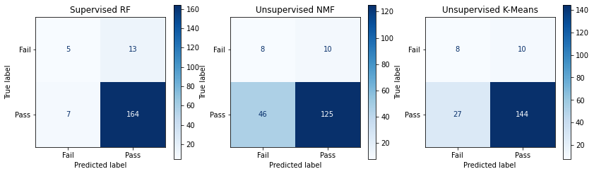

```python
from sklearn.metrics import ConfusionMatrixDisplay

#define subplots
fig, ax = plt.subplots(1,3,figsize=(14,4))
title_size = 12
cmap = 'Blues'
display_labels = ['Fail', 'Pass']

# Supervised RF
ax[0].set_title('Supervised RF', size=title_size)
ConfusionMatrixDisplay(confusion_matrix=SL_RF_cm, display_labels=display_labels).plot(
    include_values=True, ax=ax[0], cmap=cmap)
#plt.title('Supervised - Random Forest')

# Unsupervised NMF
ax[1].set_title('Unsupervised NMF', size=title_size)
ConfusionMatrixDisplay(confusion_matrix=UL_NMF_cm, display_labels=display_labels).plot(
    include_values=True, ax=ax[1], cmap=cmap)
#plt.title('Unsupervised - NMF')

# Unsupervised K-Means
ax[2].set_title('Unsupervised K-Means', size=title_size)
ConfusionMatrixDisplay(confusion_matrix=UL_KM_cm, display_labels=display_labels).plot(
    include_values=True, ax=ax[2], cmap=cmap)

plt.show()
```

For the three classifiers, the majority of the values are in the confusion matrix diagonal, revealing a fair fit. However, the classifiers struggled to properly classify the `fail` class, with none of the classifiers achieving an accuracy above 50% for the `fail` class. All in all, none of the classifiers achieved an outstanding performance, failing to properly distiguish between the classes (*pass*/*fail*)

### 5.2 Class Imbalance

Let's look at counter measures we tested to mitigate the problem of class imbalace, to evaluate if they were effective or not:

```python
clms = ['Classifier', 'osr', 'acc', 'prc', 'roc', 'avg_score']
df_osr = pd.concat([SL_df_eval[clms], NMF_df_eval[clms], KM_df_eval[clms]])
df_osr_group = df_osr.groupby(['Classifier','osr'])
df_osr_group[['acc', 'prc', 'roc', 'avg_score']].max()
```

| Classifier | osr | acc | prc | roc | avg_score |
| --- | --- | --- | --- | --- | --- |
| AB | None | 0.868182 | 0.901368 | 0.784821 | 0.841391 |
|  | ROS | 0.838636 | 0.942810 | 0.790028 | 0.837613 |
|  | SM | 0.834091 | 0.917429 | 0.754861 | 0.822289 |
| DT | None | 0.854545 | 0.897311 | 0.667590 | 0.806084 |
|  | ROS | 0.838182 | 0.900484 | 0.683521 | 0.807395 |
|  | SM | 0.818182 | 0.914973 | 0.669333 | 0.786449 |
| KMeans | None | 0.745500 | 0.872500 | 0.564500 | 0.727500 |
|  | ROS | 0.252300 | 0.767400 | 0.434200 | 0.484633 |
|  | SM | 0.254500 | 0.770100 | 0.435500 | 0.486700 |
| NMF | None | 0.811400 | 0.898300 | 0.622600 | 0.734233 |
|  | ROS | 0.822700 | 0.880000 | 0.583000 | 0.733767 |
|  | SM | 0.813600 | 0.877200 | 0.566300 | 0.728500 |
| RF | None | 0.868182 | 0.891025 | 0.843590 | 0.861127 |
|  | ROS | 0.868182 | 0.899020 | 0.811282 | 0.855950 |
|  | SM | 0.865909 | 0.915416 | 0.814769 | 0.854401 |
| SVC | None | 0.861818 | 0.884111 | 0.808000 | 0.845650 |
|  | ROS | 0.845455 | 0.949762 | 0.816821 | 0.852963 |
|  | SM | 0.838636 | 0.942844 | 0.797538 | 0.840563 |

## 6 - Conclusion

Identifying the social and demographic contributing factors in students' performance is key to the human development. In particular, analytical studies focus on improving the management of school resources to ensure a high rate of success in students educational journey.

In this project, we explore the capability of predicting if a student will pass or fail a core Portuguese course by using demographic, social and other school related data.

For achieving this goals, we implemented multiple supervised and unsupervised learning techniques evaluated under a binary target variable consisting of the student's course success/failure, with the aim of understanding which specific techniques work better than the others. The evaluated binary classification techniques were:

1. Supervised Learning  
   a) Decision Trees (DT)  
   b) Random Forests (RF)  
   c) AdaBoost (AB)  
   d) Support Vector Machines (SVM)
1. Unsupervised Learning  
   a) Non-Negative Matrix Factorization (NMF)  
   b) K-Means Clustering

That resulted in a total of 702 different learning model setups, 612 supervised and 90 unsupervised, which were evaluated using the mean of three scoring metrics: accuracy, precision, and au_roc, over the number of folds for the validation set.

The obtained results reveal that it is possible to achieve an average predictive score of the three scoring metrics of 81.3% against the test set, being Random Forest algorithm the best classifier. However, the unsupervised learning K-Means classifier achieved a similar performance of 79.4%, with less accuracy but higher au_roc, which indicates that it is a better classifier.

It is important to highlight that none of the classifiers achieved an outstanding au_roc performance, failing to properly distiguish between the classes (pass/fail).

Additionally, we observed that the problem of data imbalance and its mitigation by using oversampling techniques didn't have the expected result in improving the model capability in distiguishing the two classes. Further analysis focusing on the minority class may be required to understand the issue by using other sampling techniques.